# Conducting t-tests in R

## Example 1:

You randomly sample 5 plants of each cultivar and measure the amount of damage by collecting 20 leaves on each plant, scanning them, and using image analysis software to count the percentage of pixels with brown spots.

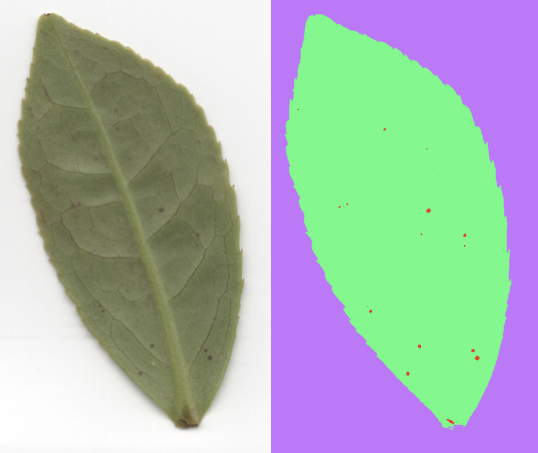

## Many possible data formats

There are many ways you might have recorded the data

For example, with a separate column for every plant:

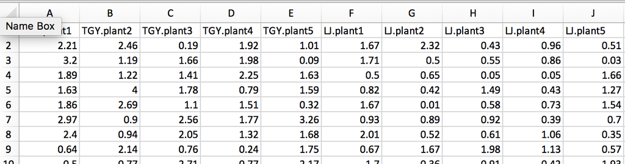

## Many possible data formats

Or with just three columns:

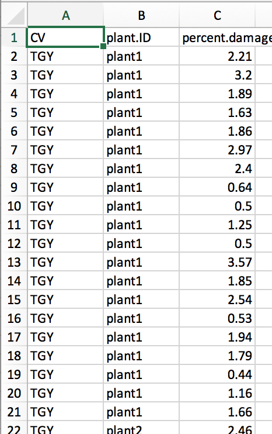

## Many possible data formats

Or using separate spreadsheets or pages for each cultivar:

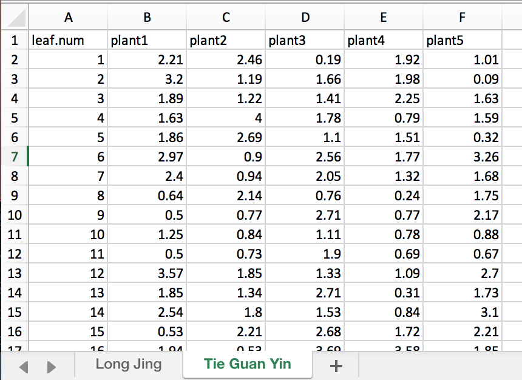